# Lista de Exercícios #2

## Questão 1

```python
import numpy as np

from sklearn.datasets import make_blobs

import seaborn as sns
import matplotlib.pyplot as plt
import matplotlib.gridspec as gridspec
```

```python
plt.rcParams.update({'font.size': 14})
```

```python
M = np.zeros((3,3))
M += .25 + np.eye(3) * .25
print(f"Matriz M:\n{M}")
```

```
Matriz M:
[[0.5  0.25 0.25]
 [0.25 0.5  0.25]
 [0.25 0.25 0.5 ]]
```

## 1.a)

```python
p0 = np.array([.3, .4, .3])
print(f"p(t=0) = {p0}")
```

```
p(t=0) = [0.3 0.4 0.3]
```

```python
p = p0
for i in range(3):
    p = np.dot(M.T, p)

print(f"p(t=3) = {p}")
```

```
p(t=3) = [0.3328125 0.334375  0.3328125]
```

## 1.b)

```python
np.random.seed(7) # força seed para garantir reprodução
rand_p = np.random.uniform(size=3)
print(f"Números aleatorios: {rand_p}")
```

```
Números aleatorios: [0.07630829 0.77991879 0.43840923]
```

Inicia no estado **1**

Iteração 1:  
[ 0.50 0.25 0.25 ]  
**[ 0.25 0.50 0.25 ]**  
[ 0.25 0.25 0.50 ]

**0.07** < (0.25) < (0.25 + 0.50) < (0.25 + 0.50 + 0.25) : logo, migra pro estado **0**

Iteração 2:  
**[ 0.50 0.25 0.25 ]**  
[ 0.25 0.50 0.25 ]  
[ 0.25 0.25 0.50 ]

(0.50) < (0.50 + 0.25) < **0.77** < (0.50 + 0.25 + 0.25) : logo, migra pro estado **2**

Iteração 3:  
[ 0.50 0.25 0.25 ]  
[ 0.25 0.50 0.25 ]  
**[ 0.25 0.25 0.50 ]**

(0.25) < **0.43** < (0.25 + 0.25) < (0.25 + 0.25 + 0.50) : logo, migra pro estado **1**

```python
X = np.zeros(4).astype(int)
X[0] = 1 # estado inicial

for i in range(3):
    # atualizacao do estado
    previous_x = X[i]
    x = np.where(M[previous_x, :].cumsum() > rand_p[i])[0][0]
    X[i+1] = x

print(f"Prova da letra B")
print(f"Sequencia de estados: {X}")
```

```
Prova da letra B
Sequencia de estados: [1 0 2 1]
```

## 1.c)

```python
n = 100
X = np.zeros((n, 4)).astype(int)

# gera estados iniciais aleatorios e equiprovaveis de 0 a 2
X[:, 0] = np.random.randint(low=0, high=3, size=(n))
#X[:, 0] = np.random.choice([0, 1, 2], p=[.6, .3, .1], size=(n)) # debug da implementaçao

# gera todos numeros aleatorios necessarios para escolher transicoes de estado
rand_p = np.random.uniform(size=(n, 3))

for i in range(n):
    for j in range(3):
        previous_x = X[i, j]

        # estado seguinte é o primeiro estado no qual a soma cumulativa das probabilidades
        # de transição é maior do que numero aleatorio escolhido
        x = np.where(M[previous_x, :].cumsum() > rand_p[i, j])[0][0]
        X[i, j+1] = x

print(f"X:\n{X}")
```

```
X:
[[0 2 2 1]
 [1 1 2 1]
 [2 0 2 1]
 [0 0 2 1]
 [1 0 0 0]
 [2 0 0 0]
 [2 2 2 2]
 [2 1 1 1]
 [0 2 2 0]
 [2 2 2 0]
 [0 0 2 0]
 [0 2 1 1]
 [0 0 2 2]
 [0 0 2 2]
```

[output cut: 86 more lines]

## 1.d)

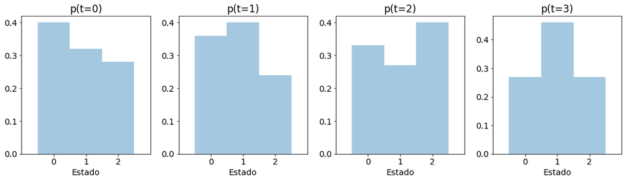

```python
plt.figure(figsize=(15, 4.5))
gs = gridspec.GridSpec(1, 4)

for i in range(4):
    ax = plt.subplot(gs[(i // 4), (i % 4)])
    hist = sns.distplot(X[:, i], norm_hist=True, bins=[-0.5, 0.5, 1.5, 2.5], kde=False, ax=ax)
    hist.set(xlim=(-1, 3))
    hist.set(xticks=[0, 1, 2])
    hist.set(title=f"p(t={i})")
    hist.set(xlabel="Estado")

plt.tight_layout()
plt.show()
```

Apesar de o modelo já começar com probabilidades equiprovaveis, o baixo número de dados provoca variação estatística como observamos na evolução dos estados no tempo.

## Questão 2

```python
J = np.array([.5, .2, .3, .1, .4])
```

## 2.a)

```python
T = 0.1

M = np.zeros((5, 5))
for orig in range(5):
    for dest in range(5):
        delta_J = J[dest] - J[orig]
        p_trans = np.minimum(np.exp(-delta_J/T), 1)
        M[orig, dest] += 1/5 * p_trans
        M[orig, orig] += 1/5 * (1 - p_trans)

print(f"Matriz M:\n{M.T}")
```

```
Matriz M:
[[0.2        0.00995741 0.02706706 0.00366313 0.07357589]
 [0.2        0.68939964 0.2        0.07357589 0.2       ]
 [0.2        0.07357589 0.49935706 0.02706706 0.2       ]
 [0.2        0.2        0.2        0.88573651 0.2       ]
 [0.2        0.02706706 0.07357589 0.00995741 0.32642411]]
```

```python
# Confere se as probabilidades de transição somam 100%
M.sum(axis=1)
```

```
array([1., 1., 1., 1., 1.])
```

## 2.b)

```python
np.random.seed(42) # força seed para garantir reprodução
rand_p = np.random.uniform(size=3)
print(f"Números aleatorios: {rand_p}")
```

```
Números aleatorios: [0.37454012 0.95071431 0.73199394]
```

Inicia no estado **1** (indice 0)

Iteração 1:  
**[ 0.20000000 0.20000000 0.20000000 0.20000000 0.20000000 ]**  
[ 0.00995741 0.68939964 0.07357589 0.20000000 0.02706706 ]  
[ 0.02706706 0.20000000 0.49935706 0.20000000 0.07357589 ]  
[ 0.00366313 0.07357589 0.02706706 0.88573651 0.00995741 ]  
[ 0.07357589 0.20000000 0.20000000 0.20000000 0.32642411 ]

(0.2) < **0.37** < (0.2 + 0.2) < (0.2 + 0.2 + 0.2) < (0.2 + 0.2 + 0.2 + 0.2) < (0.2 + 0.2 + 0.2 + 0.2 + 0.2): logo, migra pro estado **2**

Iteração 2:  
[ 0.20000000 0.20000000 0.20000000 0.20000000 0.20000000 ]  
**[ 0.00995741 0.68939964 0.07357589 0.20000000 0.02706706 ]**  
[ 0.02706706 0.20000000 0.49935706 0.20000000 0.07357589 ]  
[ 0.00366313 0.07357589 0.02706706 0.88573651 0.00995741 ]  
[ 0.07357589 0.20000000 0.20000000 0.20000000 0.32642411 ]

(0.01) < (0.01 + 0.69) < (0.01 + 0.69 + 0.07) < **0.95** < (0.01 + 0.69 + 0.07 + 0.20) < (00.01 + 0.69 + 0.07 + 0.20 + 0.02) : logo, migra pro estado **4**

Iteração 3:  
[ 0.20000000 0.20000000 0.20000000 0.20000000 0.20000000 ]  
[ 0.00995741 0.68939964 0.07357589 0.20000000 0.02706706 ]  
[ 0.02706706 0.20000000 0.49935706 0.20000000 0.07357589 ]  
**[ 0.00366313 0.07357589 0.02706706 0.88573651 0.00995741 ]**  
[ 0.07357589 0.20000000 0.20000000 0.20000000 0.32642411 ]

(0.00) < (0.00 + 0.07) < (0.00 + 0.07 + 0.02) < **0.73** < (0.00 + 0.07 + 0.02 + 0.88) < (0.00 + 0.07 + 0.02 + 0.88 + 0.01): logo, coninua no estado **4**

```python
X = np.zeros(4).astype(int)
X[0] = 0 # estado inicial (estado 1 -> indice 0)

for i in range(3):
    # atualizacao do estado
    previous_x = X[i]
    x = np.where(M[previous_x, :].cumsum() > rand_p[i])[0][0]
    X[i+1] = x

print(f"Prova da letra B")
print(f"Sequencia de estados: {X+1}") # soma 1 ao indice para obter os estados
```

```
Prova da letra B
Sequencia de estados: [1 2 4 4]
```

## 2.c)

```python
eig_vals, Q = np.linalg.eig(M.T)
```

```python
print(f"Autovalores: {eig_vals}")
for i in range(5):
    print(f"\nAutovetor associado ao autovalor {eig_vals[i]}:\n{Q[:, i]}")
```

```
Autovalores: [1.         0.68573651 0.12642411 0.48939964 0.29935706]

Autovetor associado ao autovalor 0.9999999999999996:
[-0.01703161 -0.34208911 -0.12584755 -0.9298946  -0.04629673]

Autovetor associado ao autovalor 0.685736513667068:
[-0.0263577  -0.52940857 -0.19475853  0.82217246 -0.07164766]

Autovetor associado ao autovalor 0.12642411176571153:
[-7.07106781e-01  1.45485986e-16 -9.69906575e-17 -1.61096519e-17
  7.07106781e-01]

Autovetor associado ao autovalor 0.48939964144481624:
[ 7.32526702e-02 -8.13642162e-01  5.41268090e-01  2.10605887e-15
  1.99121402e-01]

Autovetor associado ao autovalor 0.2993570551183889:
[ 2.12168062e-01 -1.08374852e-15 -7.88900650e-01  2.15174540e-16
  5.76732588e-01]
```

```python
pi = Q[:, 0]
pi = pi / pi.sum() # normaliza o vetor pi
print(f"Vetor invariante da matriz M: {pi}")
```

```
Vetor invariante da matriz M: [0.01165623 0.23412166 0.08612854 0.63640865 0.03168492]
```

```python
# prova que é o vetor invariante
np.dot(M.T, pi)
```

```
array([0.01165623, 0.23412166, 0.08612854, 0.63640865, 0.03168492])
```

## 2.d)

```python
T = 0.1
boltzmann_factors = np.exp(-J/T)
boltzmann_factors = boltzmann_factors / boltzmann_factors.sum() # normaliza os fatores
print(f"Fatores de Boltzmann dada temperatura {T}: {boltzmann_factors}")
print(f"Podemos observar que para temperatura T={T}, os fatores de boltzmann do custo J são igual ao vetor invariante pi")
```

```
Fatores de Boltzmann dada temperatura 0.1: [0.01165623 0.23412166 0.08612854 0.63640865 0.03168492]
Podemos observar que para temperatura T=0.1, os fatores de boltzmann do custo J são igual ao vetor invariante pi
```

## 2.e)

```python
T = np.array([0.1000, 0.0631, 0.0500, 0.0431, 0.0387, 0.0356, 0.0333, 0.0315, 0.0301, 0.0289])
N = 1000
```

```python
def simulated_anneling(J, N, T, s0):
    """
    J: vetor de custo associado a cada estado
    N: número de iterações de metropolis
    T: vetor de temperaturas utilizadas
    s0: estado inicial
    """

    X = np.zeros((N*len(T) + 1), dtype=int) # vetor com historico dos estados
    X[0] = s0 - 1 # transforma de estado para indice

    i = 0
    for t in T:
        for _ in range(N):
            x_candidate = np.random.randint(low=0, high=5)
            delta_J = J[x_candidate] - J[X[i]]
            q = np.exp(-delta_J/t)
            r = np.random.uniform(low=0., high=1.)

            if r < q:
                X[i+1] = x_candidate
            else:
                X[i+1] = X[i]

            i = i + 1

    S = X + 1 # transforma de indice para estados
    return S
```

```python
S = simulated_anneling(J, N, T, 0)
```

```
Distribuição dos últimos 200 estados de cada temperatura
```

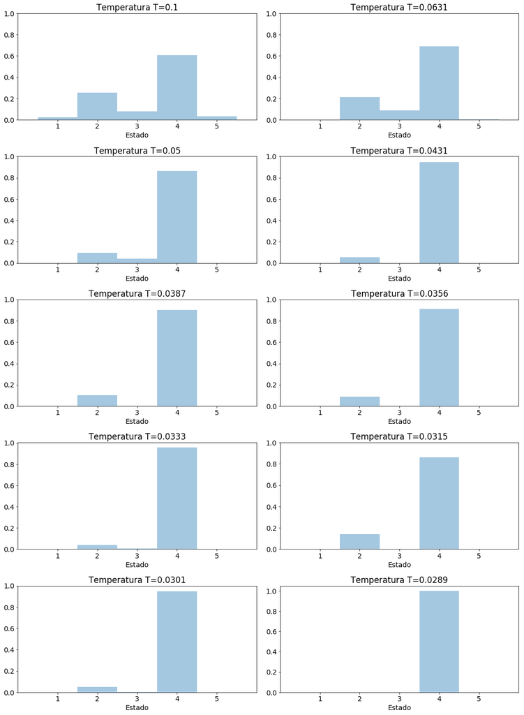

```python
print("Distribuição dos últimos 200 estados de cada temperatura")
plt.figure(figsize=(15,40))
gs = gridspec.GridSpec(10, 2)

for i, t in enumerate(T):
    ax = plt.subplot(gs[(i // 2), (i % 2)])

    # pega todos o historio de estados de uma dada temperatura
    S_t = S[((i * N) + 1):(((i+1) * N) + 1)]

    # considera apenas os ultimos 200 estados desta temperatura
    S_t = S_t[-200:]

    hist = sns.distplot(S_t, norm_hist=True, bins=[0.5, 1.5, 2.5, 3.5, 4.5, 5.5], kde=False, ax=ax)
    hist.set(xlim=(0, 6))
    hist.set(xticks=[1, 2, 3, 4, 5])
    hist.set(yticks=np.linspace(0, 1, 6))
    hist.set(title=f"Temperatura T={t}")
    hist.set(xlabel="Estado")

plt.tight_layout()
plt.show()
```

## 3)

```python
# gera os dados
n_samples = 30
X, y = make_blobs(n_samples=n_samples, n_features=2, cluster_std=[.6, .5],
                  centers=[(1, 2), (-0.5, -1)], shuffle=True, random_state=7)

# calcula centro dos clusters
c = np.zeros((2,2))
for i, cluster in enumerate(np.unique(y)):
    c[i, :] = X[y == cluster].mean(axis=0)
```

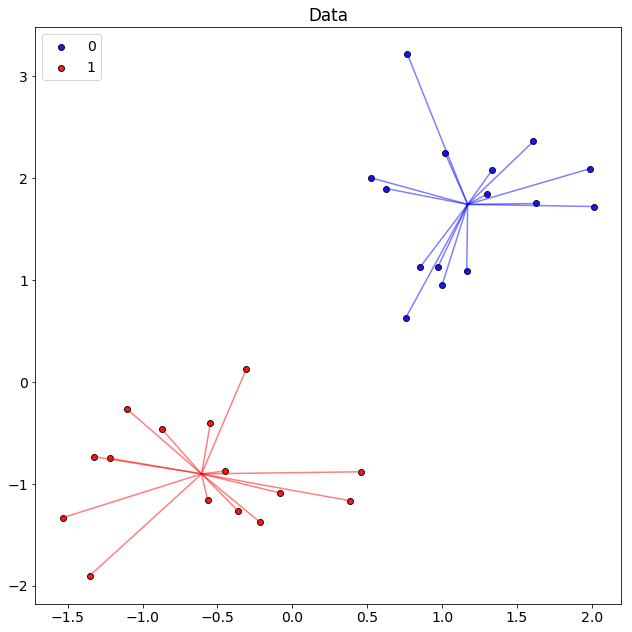

```python
# visualização dos dados

plt.figure(figsize=(9, 9))
y_unique = np.unique(y)
colors = ['b', 'r']
for cluster_value, color in zip(y_unique, colors):
    cluster_X = X[y == cluster_value]

    plt.scatter(cluster_X[:, 0], cluster_X[:, 1], c=color,
                alpha=0.9, edgecolor='k', label=cluster_value)

    for x in cluster_X:
        plt.plot([c[cluster_value, 0], x[0]], [c[cluster_value, 1], x[1]],
                 c=color, alpha=.5, markersize=10)


plt.legend(loc="upper left")
plt.title("Data")

plt.tight_layout()
plt.show()
```

```python
print(f"Ponto de mínimo determinado pela posição dos centros de clusters.")
print(f"Centro dos clusters: {c[0, :]} e {c[1, :]}")
```

```
Ponto de mínimo determinado pela posição dos centros de clusters.
Centro dos clusters: [1.17118778 1.74114274] e [-0.60639256 -0.90198388]
```

Usaremos simulated anneling com perturbação discreta.  
O centro dos clusters será calculado a partir da média dos pontos da classe.  
A função custo será a distancia geométrica entre o ponto e o centro do seu cluster.

```python
def cluster_J(X, y, n_clusters):
    """
    Calcula norma l2 média entre ponto e centro do cluster
    """

    d = np.zeros(X.shape) # distance between point and clusters
    for i in range(n_clusters):
        c = X[y == i].mean(axis=0) # cluster center
        d[y == i] = X[y == i] - c

    return np.sqrt((d**2).sum(axis=1)).mean()


def clustering_simulated_anneling(X, n_clusters, J, N, K, t0):
    """
    X: posição dos pontos
    n_clusters: úmero de clusters
    J: função custo
    N: número de iterações do algoritmo de metropolis
    K: número de iterações do simulated anneling
    t0: temperatura inicial
    """

    sample_size = X.shape[0]

    Y = np.zeros((K*N+1, sample_size), dtype=int) # matriz de historico dos estados
    Y[0] = np.random.randint(n_clusters, size=sample_size) # estado inicial

    i = 0
    for k in range(1, K+1):
        t = t0 / np.log2(1+k)

        for _ in range(N):

            # define perturbação
            cand_y = Y[i, :].copy()
            cand_idx = np.random.randint(low=0, high=sample_size)
            cand_cluster = np.random.randint(n_clusters)
            cand_y[cand_idx] = cand_cluster

            delta_J = J(X, cand_y, n_clusters) - J(X, Y[i, :], n_clusters)
            q = np.exp(-delta_J/t)
            r = np.random.uniform(low=0., high=1.)

            if r < q:
                Y[i+1] = cand_y
            else:
                Y[i+1] = Y[i]

            i = i + 1

    # Retorna historico de estados
    return Y
```

```python
Y_hat = clustering_simulated_anneling(X, n_clusters=2, J=cluster_J, N=8000, K=8, t0=0.05)
```

```python
# seleciona o ultimo estado gerado
y_hat = Y_hat[-1, :]
```

```python
c_hat = np.zeros((2,2))
for i, cluster in enumerate(np.unique(y_hat)):
    c_hat[i, :] = X[y_hat== cluster].mean(axis=0)
```

```python
print(f"Vetor original de clusters:\n{y}\n")
print(f"Vetor de clusters obtido por simulated anneling:\n{y_hat}\n")
print(f"Centro original dos clusters:\n({c[0,:]}, {c[1,:]}\n")
print(f"Centro obtido dos clusters:\n({c_hat[0,:]}, {c_hat[1,:]}")
```

```
Vetor original de clusters:
[0 1 1 1 1 0 0 0 1 0 1 1 0 0 0 0 1 0 1 0 1 1 1 0 1 0 1 1 0 0]

Vetor de clusters obtido por simulated anneling:
[1 0 0 0 0 1 1 1 0 1 0 0 0 1 1 1 0 1 0 1 0 0 0 1 0 1 0 0 1 1]

Centro original dos clusters:
([1.17118778 1.74114274], [-0.60639256 -0.90198388]

Centro obtido dos clusters:
([-0.49570078 -0.77785456], [1.17165291 1.78807542]
```

```python
J_min = cluster_J(X, y, 2)

J_hist = np.zeros(Y_hat.shape[0])
for i in range(Y_hat.shape[0]):
    J_hist[i] = cluster_J(X, Y_hat[i, :], 2)
```

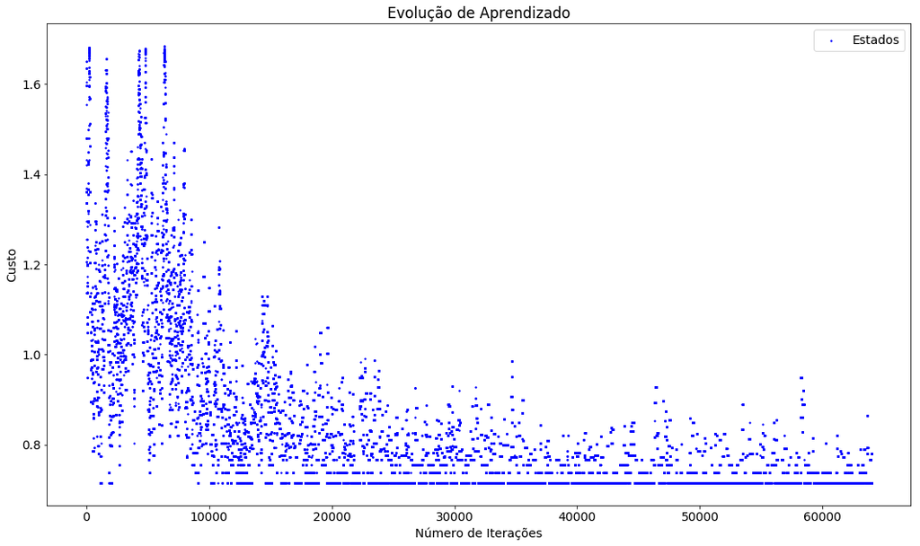

```python
# visualização da evolução da função custo

plt.figure(figsize=(15, 9))

J_hist_mean = J_hist[:-1].reshape((-1,500))[:, 0]
J_hist_std = np.abs(J_hist[:-1].reshape((-1, 500)).std(axis=1))

#plt.axhline(J_min, color='r', label='Solução Ótima')
plt.scatter(range(len(J_hist)), J_hist, s=2, color='b', label='Estados')

plt.legend(loc="upper right")
plt.title("Evolução de Aprendizado")
plt.ylabel("Custo")
plt.xlabel("Número de Iterações")

plt.tight_layout()
plt.show()
```